# Data Visualization

In this part we conduct exploratory analysis

```python
import pandas as pd
import numpy as np
import seaborn as sns
import matplotlib.pyplot as plt
import warnings

warnings.filterwarnings('ignore')
sns.set_theme(style="whitegrid")
data = pd.read_csv('../dataset/processed/cleanedData.csv')
data.head()
```

|  | Movie_Title | Movie_ID | Budget | Cast | Crew | Studios | Genre | Keywords | Languages | Countries | Release_Data | Runtime | Gross_worldwide | Rating | Rating_Count | ListOfCertificate | Release_Year | Release_Month | Release_Day |
| --- | --- | --- | --- | --- | --- | --- | --- | --- | --- | --- | --- | --- | --- | --- | --- | --- | --- | --- | --- |
| 0 | Star Wars: Episode VII - The Force Awakens | 2488496 | 245000000 | ['Daisy Ridley', 'John Boyega', 'Oscar Isaac',... | ['Lawrence Kasdan', 'Michael Arndt', 'J.J. Abr... | ['Lucasfilm', 'Bad Robot', 'Truenorth Producti... | ['Action', 'Adventure', 'Sci-Fi'] | ['reboot', 'sanitation employee', 'remake', 'c... | ['English'] | ['United States'] | 2015-12-18 | 138 | 2069521700 | 7.8 | 893000 | ['PG-13'] | 2015 | 12 | 18 |
| 1 | Frozen II | 4520988 | 150000000 | ['Kristen Bell', 'Idina Menzel', 'Josh Gad', '... | ['Jennifer Lee', 'Hans Christian Andersen', 'C... | ['Walt Disney Animation Studios', 'Walt Disney... | ['Animation', 'Adventure', 'Comedy', 'Family',... | ['autumn', 'anthropomorphic snowman', 'princes... | ['English'] | ['United States'] | 2019-11-22 | 103 | 1450026933 | 6.8 | 156000 | ['PG'] | 2019 | 11 | 22 |
| 2 | The Dark Knight Rises | 1345836 | 250000000 | ['Christian Bale', 'Tom Hardy', 'Anne Hathaway... | ['Jonathan Nolan', 'Christopher Nolan', 'David... | ['Warner Bros.', 'Legendary Entertainment', 'D... | ['Action', 'Crime', 'Drama'] | ['dc comics', 'batman character', 'bruce wayne... | ['English', 'Arabic'] | ['United Kingdom', 'United States'] | 2012-07-27 | 164 | 1081142612 | 8.4 | 1600000 | ['PG-13'] | 2012 | 7 | 27 |
| 3 | Beauty and the Beast | 2771200 | 160000000 | ['Emma Watson', 'Dan Stevens', 'Luke Evans', '... | ['Evan Spiliotopoulos', 'Bill Condon', 'Stephe... | ['Mandeville Films', 'Walt Disney Pictures'] | ['Adventure', 'Family', 'Fantasy', 'Musical', ... | ['beast', 'fairy tale', 'heroine', "beast's he... | ['English'] | ['United States'] | 2017-03-17 | 129 | 1273576220 | 7.1 | 293000 | ['PG'] | 2017 | 3 | 17 |
| 4 | Finding Dory | 2277860 | 200000000 | ['Ellen DeGeneres', 'Albert Brooks', "Ed O'Nei... | ['Angus MacLane', 'Victoria Strouse', 'Andrew ... | ['Pixar Animation Studios', 'Walt Disney Pictu... | ['Animation', 'Adventure', 'Comedy', 'Family'] | ['fish', 'ocean', 'whale', 'octopus driving a ... | ['English', 'Indonesian'] | ['United States'] | 2016-06-17 | 97 | 1028570942 | 7.3 | 259000 | ['PG'] | 2016 | 6 | 17 |

Load list fields

```python
import ast

cols = ['Cast', 'Genre', 'Studios', 'ListOfCertificate', 'Keywords', 'Languages', 'Countries']
for col in cols:
    data[col] = data[col].apply(ast.literal_eval)
```

## Process multivalued fields with Money and Count

Input:

- `dataframe`: dataframe need to be process
- `col_name`: Name of the columns we want to process. In this project they are **Cast**, **Genre** or **Studios**

Output: A dataframe contains information related to the columns combined with Money and Count

```python
def parse_with_money_and_count(dataframe, col_name):
    result = []
    count = []
    gross = []
    for i, record in enumerate(dataframe[col_name]):
        for x in record:
            # Save results to the corresponding array
            result.append(x)
            gross.append(dataframe['Gross_worldwide'][i])
            count.append(1)
    # Make dataframe
    t = pd.DataFrame({col_name: result, 'Money': gross, 'Count': count})
    # Remove duplicates and sum up corresponding columns
    result = t.groupby(col_name).sum()
    # Rearrange dataFrame
    sort_by_money = result.sort_values('Money', ascending=False)
    return sort_by_money
```

## Brief information about the dataset

```python
data.describe()
```

|  | Movie_ID | Budget | Runtime | Gross_worldwide | Rating | Rating_Count | Release_Year | Release_Month | Release_Day |
| --- | --- | --- | --- | --- | --- | --- | --- | --- | --- |
| count | 8.752000e+03 | 8.752000e+03 | 8752.000000 | 8.752000e+03 | 8752.000000 | 8.752000e+03 | 8752.000000 | 8752.000000 | 8752.000000 |
| mean | 1.044857e+06 | 2.351613e+07 | 107.962751 | 7.172680e+07 | 6.430884 | 8.347387e+04 | 2000.010398 | 6.688643 | 16.042162 |
| std | 1.743793e+06 | 3.713278e+07 | 19.695128 | 1.564077e+08 | 1.005946 | 1.641414e+05 | 13.471522 | 3.416011 | 8.602773 |
| min | 1.234900e+04 | 0.000000e+00 | 0.000000 | 9.500000e+01 | 1.400000 | 0.000000e+00 | 1921.000000 | 1.000000 | 1.000000 |
| 25% | 1.023130e+05 | 0.000000e+00 | 95.000000 | 4.443069e+06 | 5.800000 | 7.100000e+03 | 1991.000000 | 4.000000 | 9.000000 |
| 50% | 2.504325e+05 | 1.000000e+07 | 105.000000 | 1.821152e+07 | 6.500000 | 2.600000e+04 | 2002.000000 | 7.000000 | 16.000000 |
| 75% | 1.221610e+06 | 3.000000e+07 | 117.000000 | 6.560984e+07 | 7.200000 | 8.600000e+04 | 2011.000000 | 10.000000 | 23.000000 |
| max | 1.103237e+07 | 3.560000e+08 | 357.000000 | 2.847246e+09 | 9.300000 | 2.500000e+06 | 2021.000000 | 12.000000 | 31.000000 |

## Heatmap of Correlation Matrix, Histogram and Scatter Matrix

[output not shown]

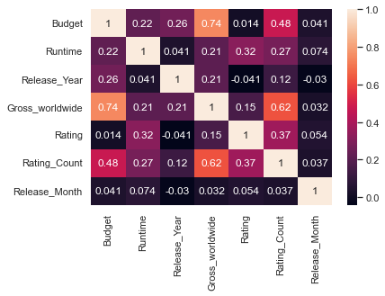

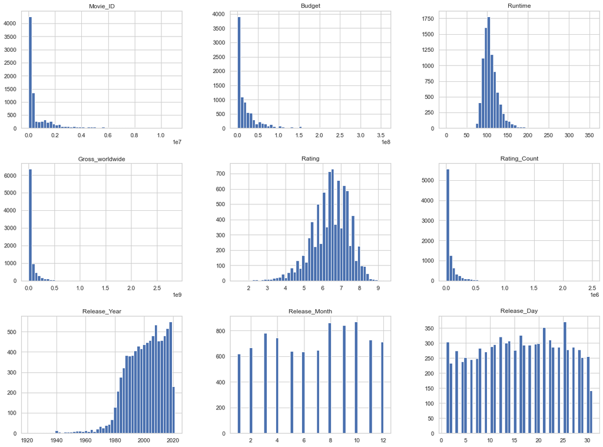

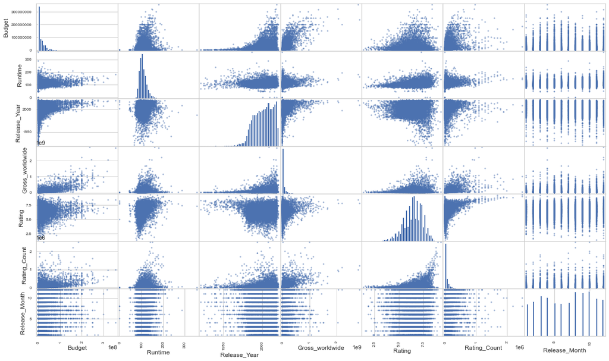

```python
from pandas.plotting import scatter_matrix

cols = ['Budget', 'Runtime', 'Release_Year', 'Gross_worldwide', 'Rating', 'Rating_Count', 'Release_Month']
info = data[cols]
sns.heatmap(info.corr(), annot=True)

data.hist(bins=50, figsize=(20, 15))

scatter_matrix(info, figsize=(20, 12), hist_kwds={'bins': 50})
```

## Average worldwide gross on each `Genre`

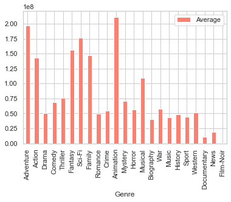

```python
genre = parse_with_money_and_count(data, 'Genre')
genre.reset_index(inplace=True)
genre = genre.assign(Average=genre['Money'] / genre['Count'])
genre.plot.bar(x='Genre', y='Average', color="salmon")
```

## How average gross depends on `Release_Month` and `Release_Year`

[output not shown]

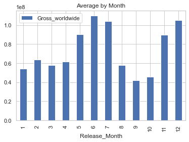

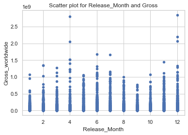

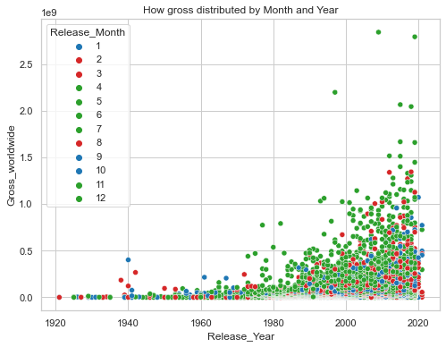

```python
cols = ['Release_Month', 'Gross_worldwide']

month = data[cols]
month = month.groupby("Release_Month").mean().reset_index()
#1
month.plot.bar(x='Release_Month', y='Gross_worldwide')
plt.title("Average by Month")
#2
data.plot.scatter(x='Release_Month', y='Gross_worldwide')
plt.title("Scatter plot for Release_Month and Gross")
#3
rColor = [2, 3, 8]
gColor = [4, 5, 6, 7, 11, 12]
bColor = [1, 9, 10]
colorMap = dict()
for i in rColor:
    colorMap[i] = 'tab:red'
for i in gColor:
    colorMap[i] = 'tab:green'
for i in bColor:
    colorMap[i] = 'tab:blue'
color_palette = colorMap
fig = plt.figure(figsize=(8, 6))
sns.scatterplot(data=data, x='Release_Year', y='Gross_worldwide', hue='Release_Month',palette=color_palette)
plt.title("How gross distributed by Month and Year")
plt.show()
```

## Relationship between `Budget` and `Gross_worldwide`

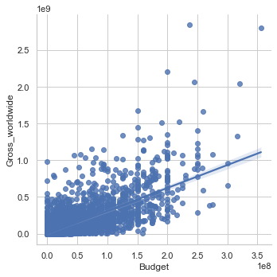

```python
sns.lmplot(data=data, x='Budget', y='Gross_worldwide')
```

`Budget` and `Gross_worldwide` may have linear relationship

## Cast actors and gross

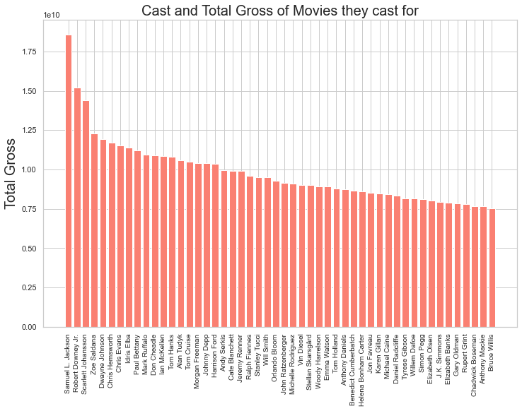

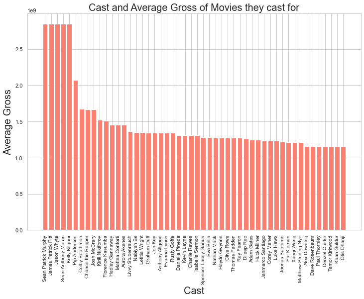

```python
cast = parse_with_money_and_count(data, 'Cast')
cast.reset_index(inplace=True)
cast = cast.assign(Average=cast['Money'] / cast['Count'])
fig = plt.figure(figsize=(12, 8))
# plt.subplot(2,1,1)
data2 = cast.sort_values(by='Money', ascending=False)[0:50]
plt.bar(data=data2, x='Cast', height='Money', color="salmon")
plt.xticks(rotation=90, fontsize=10)
plt.ylabel("Total Gross", fontsize=20)
plt.title("Cast and Total Gross of Movies they cast for", fontsize=20)
fig = plt.figure(figsize=(12, 8))
# plt.subplot(2,1,2)
data3 = cast.sort_values(by='Average', ascending=False)[0:50]
plt.bar(data=data3, x='Cast', height='Average', color="salmon")
plt.xticks(rotation=90, fontsize=10)
plt.title("Cast and Average Gross of Movies they cast for", fontsize=20)
plt.xlabel("Cast", fontsize=20)
plt.ylabel("Average Gross", fontsize=20)
plt.show()
```

We may build a ranking on cast members based on this observation. This ranking can be applied to grade them.

## Studio and total gross

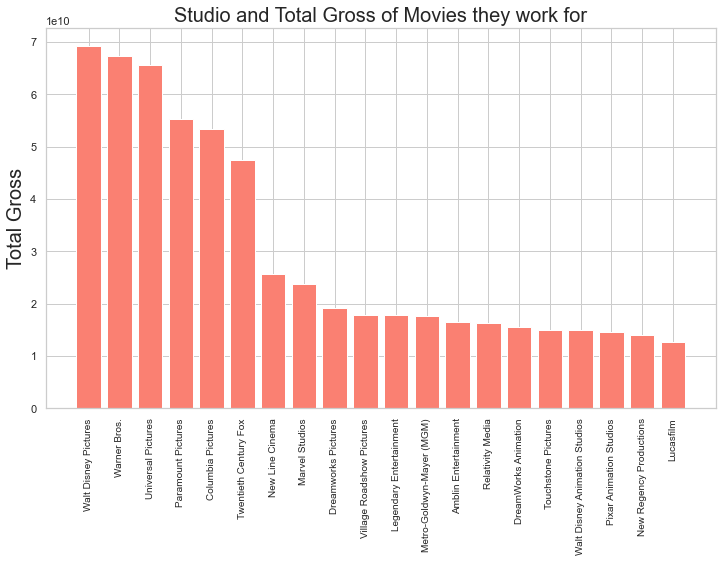

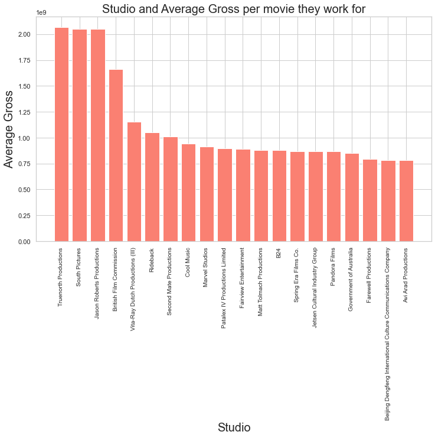

```python
studio = parse_with_money_and_count(data, 'Studios')
studio.reset_index(inplace=True)
studio = studio.assign(Average=studio['Money'] / studio['Count'])
fig = plt.figure(figsize=(12, 7))
# plt.subplot(2,1,1)
data2 = studio.sort_values(by='Money', ascending=False)[0:20]
plt.bar(data=data2, x='Studios', height='Money', color="salmon")
plt.xticks(rotation=90, fontsize=10)
plt.ylabel("Total Gross", fontsize=20)
plt.title("Studio and Total Gross of Movies they work for", fontsize=20)
plt.show()
# plt.subplot(2,1,2)
fig = plt.figure(figsize=(12, 7))
data3 = studio.sort_values(by='Average', ascending=False)[0:20]
plt.bar(data=data3, x='Studios', height='Average', color="salmon")
plt.xticks(rotation=90, fontsize=10)
plt.title("Studio and Average Gross per movie they work for", fontsize=20)
plt.xlabel("Studio", fontsize=20)
plt.ylabel("Average Gross", fontsize=20)
plt.show()
```

We may build a ranking on filming studios. However, in this observation the case where studios cooperate is not included.

## Average gross of each country and Total Gross

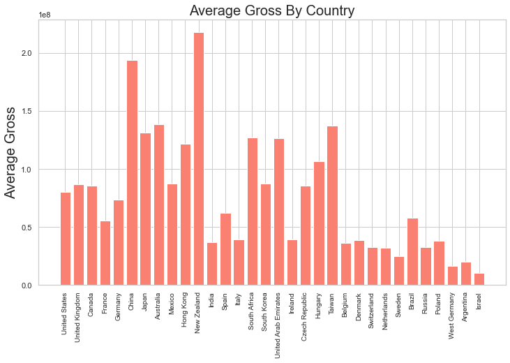

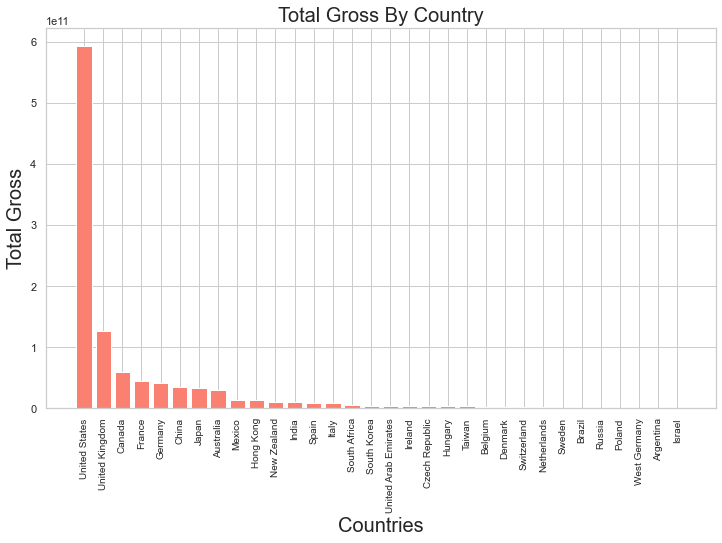

```python
country = parse_with_money_and_count(data, 'Countries')
country = country[country['Count'] > 20]
country.reset_index(inplace=True)
country = country.assign(Average=country['Money'] / country['Count'])
fig = plt.figure(figsize=(12, 7))
# plt.subplot(2,1,1)
data2 = country.sort_values(by='Money', ascending=False)
plt.bar(data=data2, x='Countries', height='Average', color="salmon")
plt.xticks(rotation=90, fontsize=10)
plt.ylabel("Average Gross", fontsize=20)
plt.title("Average Gross By Country", fontsize=20)
fig = plt.figure(figsize=(12, 7))
# plt.subplot(2,1,2)
plt.bar(data=data2, x='Countries', height='Money', color="salmon")
plt.ylabel("Total Gross", fontsize=20)
plt.xticks(rotation=90, fontsize=10)
plt.xlabel("Countries", fontsize=20)
plt.title("Total Gross By Country", fontsize=20)
plt.show()
## This use for QUESTION 8
list_country = list(country['Countries'])
```

The United States surpass all other countries in gross. This is comprehensible since the movie industry in this country is highly invested and developed.

## Distribution of gross over countries

Divide `gross` and `budget` on each part of record

```python
def splitMultivaluedField(dataframe, colName):
    result = []
    budget = []
    gross = []
    for i, record in enumerate(dataframe[colName]):
        for x in record:
            # Save results to corresponding arrays
            result.append(x)
            budget.append(dataframe['Budget'][i] / len(record))  # Divide here
            gross.append(dataframe['Gross_worldwide'][i] / len(record))  # Divide here
    # Create dataFrame
    t = pd.DataFrame({colName: result, 'Budget': budget, 'Money': gross})
    # Rearrange dataFrame
    sort_by_money = t.sort_values('Money', ascending=False)
    return sort_by_money
```

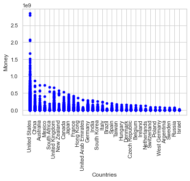

```python
country = splitMultivaluedField(data, 'Countries')
country = country[country['Countries'].isin(list_country)]
plt.figure(figsize=(16, 9))
# sns.scatterplot(data=country,x='Budget',y='Money',hue='Countries')
country.plot.scatter(x='Countries', y='Money', color='blue')
plt.xticks(rotation=90)
plt.show()
```

We may build ranking on countries based on gross

## Question 9

How distribution of gross by Languages

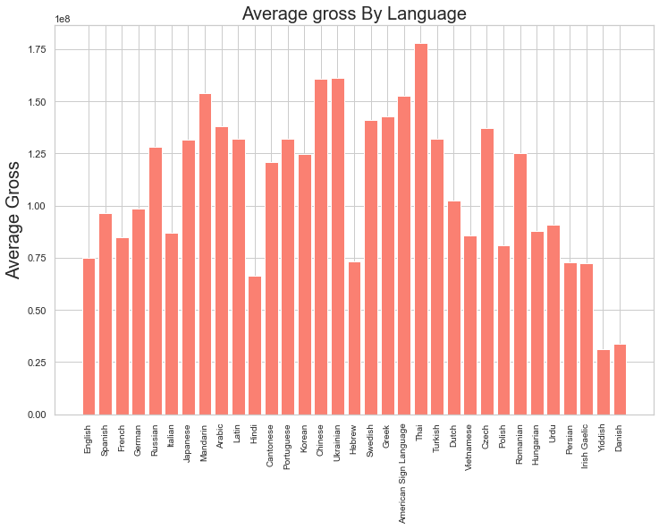

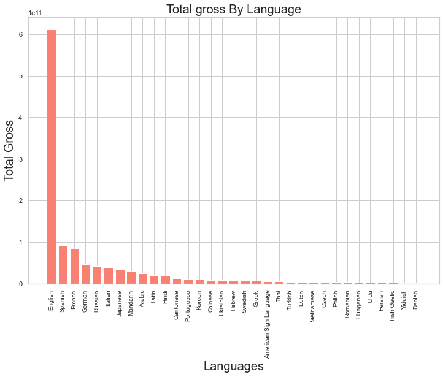

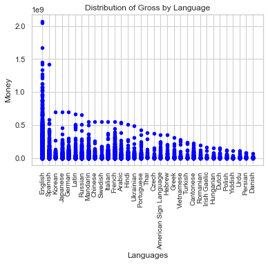

```python
language = parse_with_money_and_count(data, 'Languages')
language = language[language['Count'] > 20]
language.reset_index(inplace=True)
language = language.assign(Average=language['Money'] / language['Count'])

fig = plt.figure(figsize=(12, 8))
# plt.subplot(2,1,1)
data2 = language.sort_values(by='Money', ascending=False)
plt.bar(data=data2, x='Languages', height='Average', color="salmon")
plt.xticks(rotation=90, fontsize=10)
plt.ylabel("Average Gross", fontsize=20)
plt.title("Average gross By Language", fontsize=20)
plt.show()

# plt.subplot(2,1,2)
fig = plt.figure(figsize=(12, 8))
plt.bar(data=data2, x='Languages', height='Money', color="salmon")
plt.ylabel("Total Gross", fontsize=20)
plt.xticks(rotation=90, fontsize=10)
plt.xlabel("Languages", fontsize=20)
plt.title("Total gross By Language", fontsize=20)
plt.show()
#Top languages
listLanguage = list(data2['Languages'])

language = splitMultivaluedField(data, 'Languages')
language = language[language['Languages'].isin(listLanguage)]
plt.figure(figsize=(12, 8))
#sns.scatterplot(data=country,x='Budget',y='Money',hue='Countries')
language.plot.scatter(x='Languages', y='Money', color='blue')
plt.xticks(rotation=90, fontsize=10)
plt.title("Distribution of Gross by Language")
plt.show()
```

## Distribution of gross by `Keywords`

Since we will not divide gross to each keyword, we redefine the function `splitMultivaluedField()`

```python
def split_multi_value_field(dataframe, colName):
    result = []
    gross = []
    budget = []
    for i, record in enumerate(dataframe[colName]):
        for x in record:
            #Lưu kết quả vào mảng tương ứng
            result.append(x)
            budget.append(dataframe['Budget'][i])
            gross.append(dataframe['Gross_worldwide'][i])
    #Tạo dataFrame
    t = pd.DataFrame({colName: result, 'Budget': budget, 'Money': gross})
    #Sắp xếp lại dataFrame
    sort_by_money = t.sort_values('Money', ascending=False)
    return sort_by_money
```

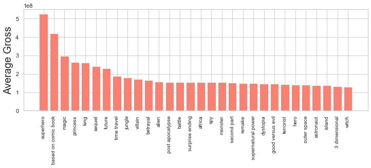

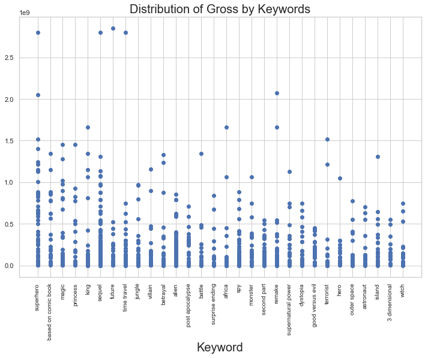

```python
keyword = parse_with_money_and_count(data, 'Keywords')
keyword = keyword[keyword['Count'] > 20]
keyword.reset_index(inplace=True)
keyword = keyword.assign(Average=keyword['Money'] / keyword['Count'])
fig = plt.figure(figsize=(12, 8))
plt.subplot(2, 1, 1)
data2 = keyword.sort_values(by='Average', ascending=False)[0:30]
plt.bar(data=data2, x='Keywords', height='Average', color="salmon")
plt.xticks(rotation=90, fontsize=10)
plt.ylabel("Average Gross", fontsize=20)

listKeywords = list(data2['Keywords'])

keyword = split_multi_value_field(data, 'Keywords')
keyword = keyword[keyword['Keywords'].isin(listKeywords)]

fig, ax = plt.subplots(figsize=(12, 8))
max = np.max(keyword['Money'])
sentinel, = ax.plot(listKeywords, np.linspace(0, max, len(listKeywords)))
sentinel.remove()

ax = plt.scatter(data=keyword, x='Keywords', y='Money')
plt.xticks(rotation=90, fontsize=10)
plt.xlabel("Keyword", fontsize=20)
plt.title("Distribution of Gross by Keywords", fontsize=20)
plt.show()
```

We may conduct keyword rank

## Distribution of gross by MPAA Certificate

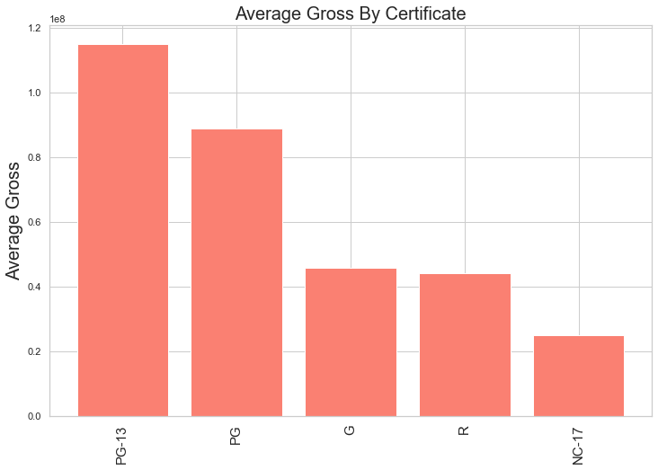

```python
certificate = parse_with_money_and_count(data, 'ListOfCertificate')
certificate.reset_index(inplace=True)
certificate = certificate.assign(Average=certificate['Money'] / certificate['Count'])
fig = plt.figure(figsize=(12, 8))
data2 = certificate.sort_values(by='Average', ascending=False)
plt.bar(data=data2, x='ListOfCertificate', height='Average', color="salmon")
plt.xticks(rotation=90, fontsize=15)
plt.ylabel("Average Gross", fontsize=20)
plt.title("Average Gross By Certificate", fontsize=20)
plt.show()
```

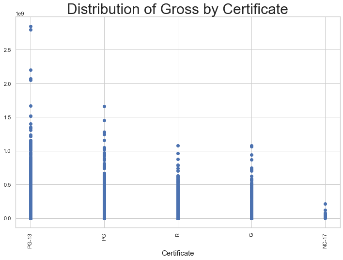

```python
certificate = split_multi_value_field(data, 'ListOfCertificate')
fig, ax = plt.subplots(figsize=(12, 8))
ax = plt.scatter(data=certificate, x='ListOfCertificate', y='Money')
plt.xticks(rotation=90)
plt.xlabel("Certificate", fontsize=15)
plt.title("Distribution of Gross by Certificate", fontsize=30)
plt.show()
```

We may conduct certificate rank